# Class One Getting Started

Kim Johnson

January 18, 2018

## Lecture Outline

- Class Introductions
- Review course outline (open from Github website: https://github.com/kijohnson/Advanced-Data-Analysis)
- Getting started with data analysis

## Getting help with R and R errors

- My advice: Google the problem or error message to try to find a solution.
- Coders are a tribe of people from all over the world who help each other
- From talking to people who code for a living and from my own personal experience, this is a standard problem solving (and learning) approach
- Consult R help often by typing *help(topic)* in the console or by searching for the topic in the help window!

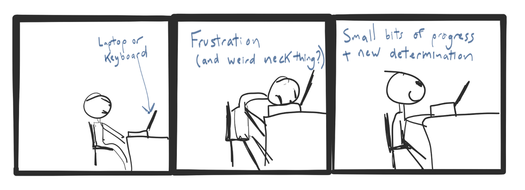

## Learning objectives

- Understand typical project workflow
- Be able to import data
- Be able to characterize the dataset
- Clean up variables
- Derive one variable
- Calculate simple statistics

## Example project workflow

[figure not shown]

## A refresher on basic stats tasks in R

- Installing packages and libraries
- Reading in files of different types
- Characterizing the dataset
- Renaming, cleaning, and creating variables
- Simple stats (mean, median, etc.)

## Open R studio and let’s install some packages and libraries

```r
# install.packages('knitr')#for creating nicer tables
# install.packages('foreign') #for accessing foreign library of functions
# install.packages('haven') #for accessing haven library of functions
# install.packages('readr') #for accessing readr libary of functions

library(foreign)  #for reading spss file
library(haven)  #for reading stata and xpt file
library(readr)  #for reading csv file
library(knitr)  #for creating nicer tables
```

## Let’s read in some different file types

- **NOTE about copying links to datsets housed on Github:** On Github click on the file you want to import and if it is readable as is (.csv, .txt), copy and paste the link into your R code for reading the file. If not readable as is (e.g. .sav, .xpt, .dta), in the gray ‘view Raw box’, right click and select ‘open link in new window’ and copy and paste the link address, which should include the following text in the first part: https://raw.githubusercontent.com…

```r
starbucks_csv <- read_csv("https://raw.githubusercontent.com/kijohnson/Advanced-Data-Analysis/master/Class%201%20Getting%20Started/Class%20one/starbucks_datasets/starbucks_csv.csv")  #read in csv file
starbucks_stata <- read_dta("https://github.com/kijohnson/Advanced-Data-Analysis/blob/master/Class%201%20Getting%20Started/Class%20one/starbucks_datasets/starbucks_stata.dta?raw=true")  #read in stata file

starbucks_tab <- read.delim("https://raw.githubusercontent.com/kijohnson/Advanced-Data-Analysis/master/Class%201%20Getting%20Started/Class%20one/starbucks_datasets/starbucks_tab.txt")  #read in tab file
```

## read in xpt and spss files

```r
starbucks_xpt <- read_xpt("https://github.com/kijohnson/Advanced-Data-Analysis/blob/master/Class%201%20Getting%20Started/Class%20one/starbucks_datasets/starbuck_xpt.xpt?raw=true")  #read in SAS XPT file. Interesting note about this format:
#'The SAS transport format is a open format, as is required for submission of the data to the FDA.'
# (from help page when *??read_xpt* is typed into the console)


starbucks_spss <- read.spss("https://github.com/kijohnson/Advanced-Data-Analysis/blob/master/Class%201%20Getting%20Started/Class%20one/starbucks_datasets/starbucks_SPSS.sav?raw=true",
    to.data.frame = TRUE)  #read in SPSS file
```

## Characterize the datasets (no. of obs, variables, basic summary stats, missing data)

```r
dim(starbucks_xpt)
```

[1] 298 7

```r
kable(summary(starbucks_xpt))  #creates nice looking table of summary stats for each variable
```

|  | DRINK | CATEGORY | CALORIES | _FAT__G_ | CARBS_G | FIBER_G | PROT_G |
| --- | --- | --- | --- | --- | --- | --- | --- |
|  | Length:298 | Length:298 | Length:298 | Min. : 0.000 | Min. : 0.00 | Min. :0.0000 | Min. : 0.000 |
|  | Class :character | Class :character | Class :character | 1st Qu.: 0.000 | 1st Qu.:15.00 | 1st Qu.:0.0000 | 1st Qu.: 0.000 |
|  | Mode :character | Mode :character | Mode :character | Median : 2.500 | Median :32.00 | Median :0.0000 | Median : 5.000 |
|  | NA | NA | NA | Mean : 3.369 | Mean :30.75 | Mean :0.6276 | Mean : 5.566 |
|  | NA | NA | NA | 3rd Qu.: 6.000 | 3rd Qu.:45.00 | 3rd Qu.:0.0000 | 3rd Qu.:10.000 |
|  | NA | NA | NA | Max. :20.000 | Max. :71.00 | Max. :8.0000 | Max. :20.000 |
|  | NA | NA | NA | NA’s :153 | NA’s :153 | NA’s :153 | NA’s :153 |

## Renaming variables

- Point to remember about renaming: always try to use decriptive names rather than x, y, a, b, c.

```r
names(starbucks_xpt) <- c("drink", "category", "calories", "fat (g)", "carb. (g)",
    "fiber (g)", "protein (g)")  #renames variables in order of appearance
kable(summary(starbucks_xpt))  #creates 'nice' looking table of summary stats for each variable
```

|  | drink | category | calories | fat (g) | carb. (g) | fiber (g) | protein (g) |
| --- | --- | --- | --- | --- | --- | --- | --- |
|  | Length:298 | Length:298 | Length:298 | Min. : 0.000 | Min. : 0.00 | Min. :0.0000 | Min. : 0.000 |
|  | Class :character | Class :character | Class :character | 1st Qu.: 0.000 | 1st Qu.:15.00 | 1st Qu.:0.0000 | 1st Qu.: 0.000 |
|  | Mode :character | Mode :character | Mode :character | Median : 2.500 | Median :32.00 | Median :0.0000 | Median : 5.000 |
|  | NA | NA | NA | Mean : 3.369 | Mean :30.75 | Mean :0.6276 | Mean : 5.566 |
|  | NA | NA | NA | 3rd Qu.: 6.000 | 3rd Qu.:45.00 | 3rd Qu.:0.0000 | 3rd Qu.:10.000 |
|  | NA | NA | NA | Max. :20.000 | Max. :71.00 | Max. :8.0000 | Max. :20.000 |
|  | NA | NA | NA | NA’s :153 | NA’s :153 | NA’s :153 | NA’s :153 |

## Clean up calories variable/convert to numeric/find mean and median

```r
starbucks_xpt$calories_n <- as.numeric(as.character(starbucks_xpt$calories))  #convert calories variable to numeric so math can be done
summary(starbucks_xpt$calories_n)  #get summary stats
```

```
##    Min. 1st Qu.  Median    Mean 3rd Qu.    Max.    NA's
##     0.0    70.0   140.0   174.3   280.0   470.0     153
```

```r
mean(starbucks_xpt$calories_n, na.rm = TRUE)  #get mean
```

```
## [1] 174.3448
```

```r
median(starbucks_xpt$calories_n, na.rm = TRUE)  #get median
```

```
## [1] 140
```

```r
sd(starbucks_xpt$calories_n, na.rm = TRUE)  #get sd
```

```
## [1] 118.618
```

```r
var(starbucks_xpt$calories_n, na.rm = TRUE)  #get variance
```

```
## [1] 14070.23
```

```r
quantile(starbucks_xpt$calories_n, na.rm = TRUE)  #get quantile
```

```
##   0%  25%  50%  75% 100%
##    0   70  140  280  470
```

## Categorize calories as above and below the median, label level values

```r
starbucks_xpt$calories_med[starbucks_xpt$calories_n > 140] <- 1  #above median
starbucks_xpt$calories_med[starbucks_xpt$calories_n <= 140] <- 0  #below median
str(starbucks_xpt$calories_med)  #check the type of variable
```

```
##  num [1:298] 0 NA 1 NA 1 NA NA 1 NA 1 ...
```

```r
starbucks_xpt$calories_med.f <- factor(starbucks_xpt$calories_med, labels = c("Below the median",
    "Above the median"))  #change to factor variable and label levels
table(starbucks_xpt$calories_med.f)  #determine how many observations are in each level
```

```
##
## Below the median Above the median
##               73               72
```

## Find mean number of calories for ‘Starbucks Espresso Beverages’

```r
espresso <- starbucks_xpt[which(starbucks_xpt$category == "Starbucks Espresso Beverages"),
    ]  #subset espresso data (I am calling this the child dataframe)
table(starbucks_xpt$category)  #check that subsetting worked by checking number of espresso drinks in parent dataframe
```

```
##
##                   Bottled Drinks              Chocolate Beverages
##                               56                               11
##        Cold Brew and Iced Coffee       Fizzio"! Handcrafted Sodas
##                               14                                3
## Frappuccino® Blended Beverages            Freshly Brewed Coffee
##                               58                               15
##                         Iced Tea        Kids\031  Drinks & Others
##                               27                                9
##                  Lattes and Teas                        Smoothies
##                               43                                2
##     Starbucks Espresso Beverages Starbucks Refreshers"! Beverages
##                               48                               12
```

```r
dim(espresso)  #check that subsetting worked by checking number of espresso drinks in child dataframe
```

```
## [1] 48 10
```

```r
mean(espresso$calories_n, na.rm = TRUE)  #calculate mean number of calories in espresso drinks, removing 'NAs' first
```

```
## [1] 268.125
```

```r
summary(espresso$calories_n)  #another way to see the mean number of calories in espresso drinks
```

```
##    Min. 1st Qu.  Median    Mean 3rd Qu.    Max.    NA's
##    45.0   207.5   270.0   268.1   312.5   470.0       8
```

## Class activity and HW2

- Go to our Github website to download and open the class activity/HW2
- Follow the instructions on the HW2 pdf and let’s start exploring the *class1survey* data!

## If you receive error messages while installing packages/libraries, see here:

https://stackoverflow.com/questions/32932354/how-to-install-the-libraryreadr